# ODEs (MATH 2030)

# Midterm 1 chapters (1.1-1.3, 2.1, 2.2, 2.4, 2.5, 2.6, 2.8, 3.1, 3.2, 3.3, 3.4 Maybe 3.5 and 3.6) However, all section of chapters 1-3 will be included.

Textbook: Differential Equations and Boundary Value Problems

# 1.1

## Definitions

• **Differential equations**: equations containing derivatives. $$ \\ $$ • **mathematical model**: a differential equation that describes some physical processes. $$ \\ $$ • **direction/slope fields**: graphs of solutions to a differential equation. $$ \\ $$

## Direction/Slope Fields in Python

## Fundamental Steps to Graph a Direction Field/Slope Field

### Check the comments below

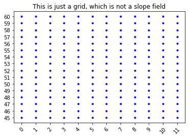

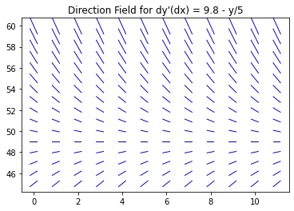

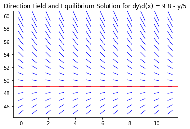

```python
#import numpy an matplotlib.pyplot
import numpy as np
import matplotlib.pyplot as plt
#step 2 is not necessary but it helps to create specific step value
#to space you lines
xstep, ystep = 1, 1
#Step 3 use the arange function
x = np.arange(0, 12, xstep)
y = np.arange(45, 61, ystep)
#Step 4 create a meshgrid
X, Y = np.meshgrid(x,y)

plt.plot(X,Y, marker=".", color="#00f" , linestyle="none")
dy = 9.8 - Y/5.0
dx = np.ones(dy.shape)
plt.yticks(y)
plt.xticks( x,rotation="45")
plt.title("This is just a grid, which is not a slope field")
plt.show()
# basically the x labels will be rotated by 45 degrees
#the code below is not an example I made; it can be found at
#https://github.com/olutosinbanjo/plots/blob/main/direction_field/falling_object.py
# there are different ways to represent examples but the fundamentals are outlined above.
def direction_field():
    plt.quiver(X, Y, dx, dy, color='#00f', headaxislength=5, headlength=0,
                pivot='middle', scale=2, linewidth=.2, units='xy', width = .05, headwidth=1)
    plt.title('Direction Field for dy\'(dx) = 9.8 - y/5')
    plt.show()

def direction_equilibrium():
    zero_index = np.where(dy == 0) # get index of zero elements
    equilibrium_solution = Y[zero_index] # get the values of V which makes dv == 0

    # Plot equilibrium position
    plt.axhline(y=equilibrium_solution[0], color='#f00', linestyle='-')

    # Plot direction field
    plt.quiver(X, Y, dx, dy, color='#00f', headaxislength=5, headlength=0,
                pivot='middle', scale=2, linewidth=.2, units='xy', width = .05, headwidth=1)
    plt.title('Direction Field and Equilibrium Solution for dy\d(x) = 9.8 - y/5')
    plt.show()

direction_field()
direction_equilibrium()
```

# 1.2

## Definitions

- **general solution**: all possible solutions of a differential equation
- **integral curves**: the family of curves that represent the geometrical representation of the general solution
- **initial condition**: a constant that the solution of an ODE equates to when the only variable of the solution to the ODE is set to 0: $\mathbf{p}(0)$
- **initial value problem**: when we need to solve an ODE along with an initial condition: $\mathbf{p}(0)$

# 1.3

## Definitions

The most importnat classification is whether the function depends on a single variable or on several variables. In the case of **single variables**, we get **ordinary diffrential equations**, whereas in the case of **several variables** we get a **partial diffrential equations**.

$$ \\ $$

• The ordinary diffrential equation $\mathbf{F}(t, y, y^{'}, \dots, y^{n}) = 0$ is said to be **linear** if $\mathbf{F}$ is a linear function of the variables $y, y^{'}, \dots, y^{n}$. Hence the general ode is of the form $a_0(t)y^{(n)} + a_1(t)y^{(n-1)} + \dots + a_n(t)y = g(t)$

$$ \\ $$

• An ODE is **non-linear** if is not of the form $a_0(t)y^{(n)} + a_1(t)y^{(n-1)} + \dots + a_n(t)y = g(t)$.

**Characteristics of non-linear ODEs**

1. If an ODE has any term such that y or any of its derivatives is multiplied by y or any of its derivatives it is non linear.
2. 1. If an ODE has any term such that y or any of its derivatives is multiplied by the free variable x, it is non-linear.

$$ \\ $$

• **Lotka-Volterra model**: a system of equation used in ecological modeling: $$\frac{dx}{dt} = ax -\alpha xy \\ \frac{dy}{dt} = -cy -\gamma xy$$ $$ \\ $$ $x(t)$ and $y(t)$ are the respective populations of the prey and predator species.

$$ \\ $$

• The order of a diffrential equation is the order of the highest derivative that appear in the equation. e.g. $\mathbf{F}[t, u(t), u^{'}(t), \dots, u^{n}(t)] = 0$ is an ordinary differential equation of the nth order. It is convinient in ODEs to write y for $u(t)$, impliying $y^{'} = u^{'}(t)$

$$ \\ $$

• **linearization**: the process of approximating a nonlinear equation by a linear one

$$ \\ $$

A solution of the ODE $ y^{n} = f(t, y, y^{'}, \dots, y^{n-1})$ on the interval $ \alpha < t < \beta$ is a function $\phi$ such that $\phi^{'}, \phi^{''}, \dots, \phi^{n}$ exist and satisfy $\phi^{n}(t) = \mathbf{f}[t, \phi(t),\phi^{'}(t), \dots, \phi^{n}(t)]$

$$ \\ $$